# PROJECT 5: Communicate Data Findings

## Introduction:

```python
import pandas as pd
import numpy as np
import matplotlib.pyplot as plt
import seaborn as sns
%matplotlib inline
```

```python
df=pd.read_csv("prosperLoanData.csv")
```

```python
df.head()
```

|  | ListingKey | ListingNumber | ListingCreationDate | CreditGrade | Term | LoanStatus | ClosedDate | BorrowerAPR | BorrowerRate | LenderYield | ... | LP_ServiceFees | LP_CollectionFees | LP_GrossPrincipalLoss | LP_NetPrincipalLoss | LP_NonPrincipalRecoverypayments | PercentFunded | Recommendations | InvestmentFromFriendsCount | InvestmentFromFriendsAmount | Investors |
| --- | --- | --- | --- | --- | --- | --- | --- | --- | --- | --- | --- | --- | --- | --- | --- | --- | --- | --- | --- | --- | --- |
| 0 | 1021339766868145413AB3B | 193129 | 2007-08-26 19:09:29.263000000 | C | 36 | Completed | 2009-08-14 00:00:00 | 0.16516 | 0.1580 | 0.1380 | ... | -133.18 | 0.0 | 0.0 | 0.0 | 0.0 | 1.0 | 0 | 0 | 0.0 | 258 |
| 1 | 10273602499503308B223C1 | 1209647 | 2014-02-27 08:28:07.900000000 | NaN | 36 | Current | NaN | 0.12016 | 0.0920 | 0.0820 | ... | 0.00 | 0.0 | 0.0 | 0.0 | 0.0 | 1.0 | 0 | 0 | 0.0 | 1 |
| 2 | 0EE9337825851032864889A | 81716 | 2007-01-05 15:00:47.090000000 | HR | 36 | Completed | 2009-12-17 00:00:00 | 0.28269 | 0.2750 | 0.2400 | ... | -24.20 | 0.0 | 0.0 | 0.0 | 0.0 | 1.0 | 0 | 0 | 0.0 | 41 |
| 3 | 0EF5356002482715299901A | 658116 | 2012-10-22 11:02:35.010000000 | NaN | 36 | Current | NaN | 0.12528 | 0.0974 | 0.0874 | ... | -108.01 | 0.0 | 0.0 | 0.0 | 0.0 | 1.0 | 0 | 0 | 0.0 | 158 |
| 4 | 0F023589499656230C5E3E2 | 909464 | 2013-09-14 18:38:39.097000000 | NaN | 36 | Current | NaN | 0.24614 | 0.2085 | 0.1985 | ... | -60.27 | 0.0 | 0.0 | 0.0 | 0.0 | 1.0 | 0 | 0 | 0.0 | 20 |

5 rows × 81 columns

```python
df.columns
```

```
Index(['ListingKey', 'ListingNumber', 'ListingCreationDate', 'CreditGrade',
       'Term', 'LoanStatus', 'ClosedDate', 'BorrowerAPR', 'BorrowerRate',
       'LenderYield', 'EstimatedEffectiveYield', 'EstimatedLoss',
       'EstimatedReturn', 'ProsperRating (numeric)', 'ProsperRating (Alpha)',
       'ProsperScore', 'ListingCategory (numeric)', 'BorrowerState',
       'Occupation', 'EmploymentStatus', 'EmploymentStatusDuration',
       'IsBorrowerHomeowner', 'CurrentlyInGroup', 'GroupKey',
       'DateCreditPulled', 'CreditScoreRangeLower', 'CreditScoreRangeUpper',
       'FirstRecordedCreditLine', 'CurrentCreditLines', 'OpenCreditLines',
       'TotalCreditLinespast7years', 'OpenRevolvingAccounts',
       'OpenRevolvingMonthlyPayment', 'InquiriesLast6Months', 'TotalInquiries',
       'CurrentDelinquencies', 'AmountDelinquent', 'DelinquenciesLast7Years',
       'PublicRecordsLast10Years', 'PublicRecordsLast12Months',
       'RevolvingCreditBalance', 'BankcardUtilization',
       'AvailableBankcardCredit', 'TotalTrades',
       'TradesNeverDelinquent (percentage)', 'TradesOpenedLast6Months',
       'DebtToIncomeRatio', 'IncomeRange', 'IncomeVerifiable',
       'StatedMonthlyIncome', 'LoanKey', 'TotalProsperLoans',
       'TotalProsperPaymentsBilled', 'OnTimeProsperPayments',
       'ProsperPaymentsLessThanOneMonthLate',
       'ProsperPaymentsOneMonthPlusLate', 'ProsperPrincipalBorrowed',
       'ProsperPrincipalOutstanding', 'ScorexChangeAtTimeOfListing',
       'LoanCurrentDaysDelinquent', 'LoanFirstDefaultedCycleNumber',
       'LoanMonthsSinceOrigination', 'LoanNumber', 'LoanOriginalAmount',
       'LoanOriginationDate', 'LoanOriginationQuarter', 'MemberKey',
       'MonthlyLoanPayment', 'LP_CustomerPayments',
       'LP_CustomerPrincipalPayments', 'LP_InterestandFees', 'LP_ServiceFees',
       'LP_CollectionFees', 'LP_GrossPrincipalLoss', 'LP_NetPrincipalLoss',
       'LP_NonPrincipalRecoverypayments', 'PercentFunded', 'Recommendations',
       'InvestmentFromFriendsCount', 'InvestmentFromFriendsAmount',
       'Investors'],
      dtype='object')
```

### Columns Description

Source: https://docs.google.com/spreadsheets/d/1gDyi_L4UvIrLTEC6Wri5nbaMmkGmLQBk-Yx3z0XDEtI/edit#gid=0

```python
df.info()
```

```
<class 'pandas.core.frame.DataFrame'>
RangeIndex: 113937 entries, 0 to 113936
Data columns (total 81 columns):
 #   Column                               Non-Null Count   Dtype
---  ------                               --------------   -----
 0   ListingKey                           113937 non-null  object
 1   ListingNumber                        113937 non-null  int64
 2   ListingCreationDate                  113937 non-null  object
 3   CreditGrade                          28953 non-null   object
 4   Term                                 113937 non-null  int64
 5   LoanStatus                           113937 non-null  object
 6   ClosedDate                           55089 non-null   object
 7   BorrowerAPR                          113912 non-null  float64
 8   BorrowerRate                         113937 non-null  float64
 9   LenderYield                          113937 non-null  float64
```

[output cut: 73 more lines]

### Null Values in dataset

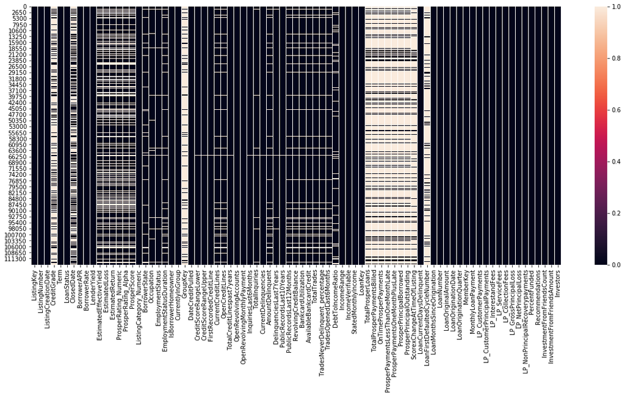

```python
fig, ax = plt.subplots(figsize = (20,8))
ax = sns.heatmap(df.isnull(), vmin=0, vmax = 1)
```

### Checking for duplicate values

**Notes:** The dataset contains alot of missing data.

```python
df[df.duplicated()]
```

|  | ListingKey | ListingNumber | ListingCreationDate | CreditGrade | Term | LoanStatus | ClosedDate | BorrowerAPR | BorrowerRate | LenderYield | ... | LP_ServiceFees | LP_CollectionFees | LP_GrossPrincipalLoss | LP_NetPrincipalLoss | LP_NonPrincipalRecoverypayments | PercentFunded | Recommendations | InvestmentFromFriendsCount | InvestmentFromFriendsAmount | Investors |
| --- | --- | --- | --- | --- | --- | --- | --- | --- | --- | --- | --- | --- | --- | --- | --- | --- | --- | --- | --- | --- | --- |

0 rows × 81 columns

**Notes:** No duplicates present

### Renaming column names

```python
df.rename(columns={'ListingCategory (numeric)' : 'ListingCategory_Numeric','ProsperRating (Alpha)': 'ProsperRating_Alpha', 'ProsperRating (numeric)': 'ProsperRating_Numeric','TradesNeverDelinquent (percentage)':'TradesNeverDelinquent_percentage'}, inplace=True)
```

### We will consider few specific columns for our data analysis

```python
# Due to many variables in this dataset, I only use few variables. Those are:
column = ['ListingKey' ,
        'ListingNumber' ,
        'Term' ,
        'LoanStatus',
        'EstimatedEffectiveYield' ,
        'BorrowerAPR' ,
        'BorrowerRate' ,
        'ProsperRating_Numeric',
        'ProsperRating_Alpha',
        'ProsperScore',
        'ListingCategory_Numeric',
        'EmploymentStatus',
        'Occupation',
        'EmploymentStatusDuration',
        'IsBorrowerHomeowner',
        'IncomeVerifiable',
        'StatedMonthlyIncome',
        'MonthlyLoanPayment',
        'Recommendations',
        'DebtToIncomeRatio',
        'LoanOriginalAmount' ,
        'PercentFunded',
        'IncomeRange',
        'Investors',
        'BorrowerState']
```

```python
loan=df[column]
loan.head()
```

|  | ListingKey | ListingNumber | Term | LoanStatus | EstimatedEffectiveYield | BorrowerAPR | BorrowerRate | ProsperRating_Numeric | ProsperRating_Alpha | ProsperScore | ... | IncomeVerifiable | StatedMonthlyIncome | MonthlyLoanPayment | Recommendations | DebtToIncomeRatio | LoanOriginalAmount | PercentFunded | IncomeRange | Investors | BorrowerState |
| --- | --- | --- | --- | --- | --- | --- | --- | --- | --- | --- | --- | --- | --- | --- | --- | --- | --- | --- | --- | --- | --- |
| 0 | 1021339766868145413AB3B | 193129 | 36 | Completed | NaN | 0.16516 | 0.1580 | NaN | NaN | NaN | ... | True | 3083.333333 | 330.43 | 0 | 0.17 | 9425 | 1.0 | $25,000-49,999 | 258 | CO |
| 1 | 10273602499503308B223C1 | 1209647 | 36 | Current | 0.07960 | 0.12016 | 0.0920 | 6.0 | A | 7.0 | ... | True | 6125.000000 | 318.93 | 0 | 0.18 | 10000 | 1.0 | $50,000-74,999 | 1 | CO |
| 2 | 0EE9337825851032864889A | 81716 | 36 | Completed | NaN | 0.28269 | 0.2750 | NaN | NaN | NaN | ... | True | 2083.333333 | 123.32 | 0 | 0.06 | 3001 | 1.0 | Not displayed | 41 | GA |
| 3 | 0EF5356002482715299901A | 658116 | 36 | Current | 0.08490 | 0.12528 | 0.0974 | 6.0 | A | 9.0 | ... | True | 2875.000000 | 321.45 | 0 | 0.15 | 10000 | 1.0 | $25,000-49,999 | 158 | GA |
| 4 | 0F023589499656230C5E3E2 | 909464 | 36 | Current | 0.18316 | 0.24614 | 0.2085 | 3.0 | D | 4.0 | ... | True | 9583.333333 | 563.97 | 0 | 0.26 | 15000 | 1.0 | $100,000+ | 20 | MN |

5 rows × 25 columns

### Null Values in loan Dataset

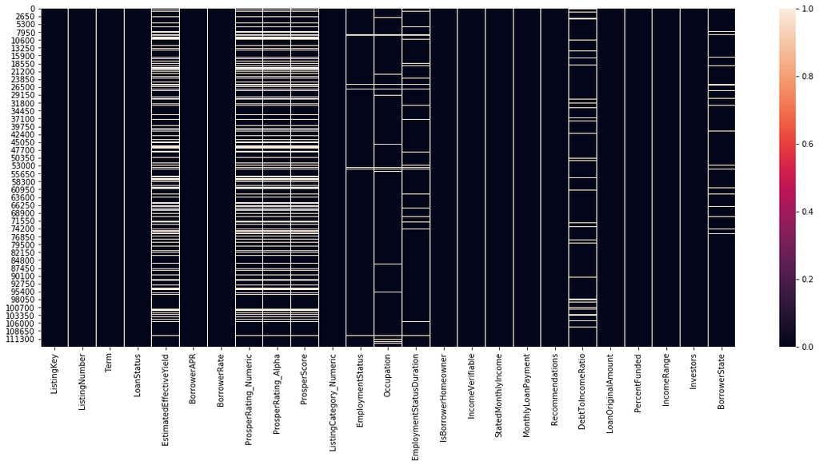

```python
fig, ax = plt.subplots(figsize = (20,8))
ax = sns.heatmap(loan.isnull(), vmin=0, vmax = 1)
```

#### Removing null Value Data for better visualisation experience

```python
loan_clean=loan.dropna()
```

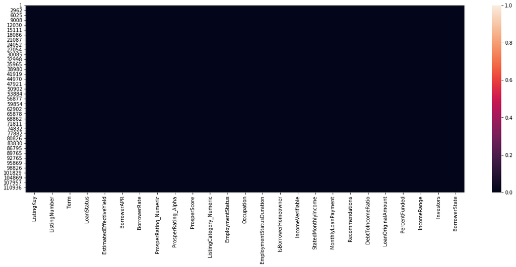

```python
fig, ax = plt.subplots(figsize = (20,7))
ax = sns.heatmap(loan_clean.isnull(), vmin=0, vmax = 1)
```

#### Note : Now we can use this loan dataset for visualisation purpose.

```python
loan_clean.info()
```

```
<class 'pandas.core.frame.DataFrame'>
Int64Index: 76216 entries, 1 to 113936
Data columns (total 25 columns):
 #   Column                    Non-Null Count  Dtype
---  ------                    --------------  -----
 0   ListingKey                76216 non-null  object
 1   ListingNumber             76216 non-null  int64
 2   Term                      76216 non-null  int64
 3   LoanStatus                76216 non-null  object
 4   EstimatedEffectiveYield   76216 non-null  float64
 5   BorrowerAPR               76216 non-null  float64
 6   BorrowerRate              76216 non-null  float64
 7   ProsperRating_Numeric     76216 non-null  float64
 8   ProsperRating_Alpha       76216 non-null  object
 9   ProsperScore              76216 non-null  float64
```

[output cut: 17 more lines]

```python
loan_clean.describe()
```

|  | ListingNumber | Term | EstimatedEffectiveYield | BorrowerAPR | BorrowerRate | ProsperRating_Numeric | ProsperScore | ListingCategory_Numeric | EmploymentStatusDuration | StatedMonthlyIncome | MonthlyLoanPayment | Recommendations | DebtToIncomeRatio | LoanOriginalAmount | PercentFunded | Investors |
| --- | --- | --- | --- | --- | --- | --- | --- | --- | --- | --- | --- | --- | --- | --- | --- | --- |
| count | 7.621600e+04 | 76216.000000 | 76216.000000 | 76216.000000 | 76216.000000 | 76216.000000 | 76216.000000 | 76216.000000 | 76216.000000 | 76216.000000 | 76216.000000 | 76216.000000 | 76216.000000 | 76216.000000 | 76216.000000 | 76216.000000 |
| mean | 7.737463e+05 | 42.760470 | 0.166738 | 0.223901 | 0.193621 | 4.132413 | 6.080246 | 3.302259 | 104.578028 | 6002.833586 | 296.421859 | 0.016571 | 0.258032 | 9294.999410 | 0.998131 | 69.998517 |
| std | 2.344166e+05 | 11.744005 | 0.067595 | 0.079372 | 0.074088 | 1.661460 | 2.360640 | 4.396670 | 95.836443 | 5110.743506 | 189.674943 | 0.187732 | 0.320587 | 6413.404265 | 0.020572 | 97.801415 |
| min | 4.162750e+05 | 12.000000 | -0.181600 | 0.045830 | 0.040000 | 1.000000 | 1.000000 | 0.000000 | 0.000000 | 0.250000 | 0.000000 | 0.000000 | 0.000000 | 1000.000000 | 0.700000 | 1.000000 |
| 25% | 5.603650e+05 | 36.000000 | 0.114800 | 0.161570 | 0.134900 | 3.000000 | 4.000000 | 1.000000 | 32.000000 | 3583.333333 | 159.062500 | 0.000000 | 0.150000 | 4000.000000 | 1.000000 | 1.000000 |
| 50% | 7.425500e+05 | 36.000000 | 0.157670 | 0.215660 | 0.184500 | 4.000000 | 6.000000 | 1.000000 | 76.000000 | 5041.666667 | 257.760000 | 0.000000 | 0.220000 | 8000.000000 | 1.000000 | 32.000000 |
| 75% | 9.747142e+05 | 60.000000 | 0.219000 | 0.287800 | 0.254900 | 5.000000 | 8.000000 | 3.000000 | 150.000000 | 7250.000000 | 392.420000 | 0.000000 | 0.320000 | 14603.250000 | 1.000000 | 100.000000 |
| max | 1.255149e+06 | 60.000000 | 0.319900 | 0.423950 | 0.360000 | 7.000000 | 11.000000 | 20.000000 | 755.000000 | 483333.333333 | 2251.510000 | 19.000000 | 10.010000 | 35000.000000 | 1.012500 | 1189.000000 |

## Univariate Exploration

### 1. Loan Original Amount

**The origination amount of the loan.**

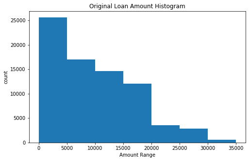

```python
plt.figure(figsize=(8, 5))
plt.hist(loan_clean.LoanOriginalAmount,bins=np.arange(0,40000,5000))
plt.title("Original Loan Amount Histogram")
plt.ylabel("count")
plt.xlabel("Amount Range")
```

**Note**: Original Loan amount is right skewed. Most of the loan amount are in range of 0-5000.

### 2. Loan Status

**The current status of the loan: Cancelled, Chargedoff, Completed, Current, Defaulted, FinalPaymentInProgress, PastDue. The PastDue status will be accompanied by a delinquency bucket.**

```python
loan_clean.LoanStatus.value_counts()
```

```
Current                   51170
Completed                 17687
Chargedoff                 4444
Defaulted                   885
Past Due (1-15 days)        714
Past Due (31-60 days)       322
Past Due (91-120 days)      277
Past Due (61-90 days)       275
Past Due (16-30 days)       241
FinalPaymentInProgress      187
Past Due (>120 days)         14
Name: LoanStatus, dtype: int64
```

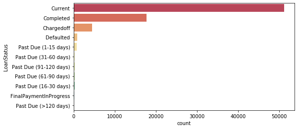

```python
plt.figure(figsize=(8, 4))
sns.countplot(data=loan_clean,y="LoanStatus",orient="v", palette="Spectral",order = loan_clean.LoanStatus.value_counts().index)
```

**Note:** Most of the Loan status is Current. Apart from it we can see alot of completed loan case.

### 3. IsBorrowerHomeowner

**A Borrower will be classified as a homowner if they have a mortgage on their credit profile or provide documentation confirming they are a homeowner.**

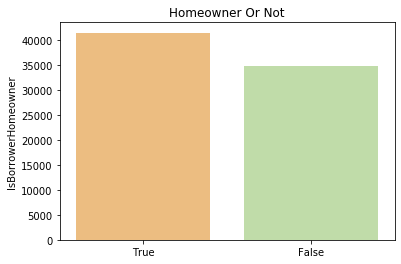

```python
sns.barplot(x=["True","False"],y=loan_clean.IsBorrowerHomeowner.value_counts(), palette="Spectral")
plt.title("Homeowner Or Not")
```

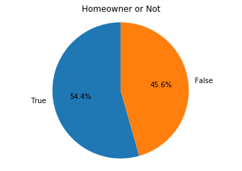

```python
plt.figure(figsize=(8, 6))
labels = loan_clean.IsBorrowerHomeowner.value_counts().index
sizes = loan_clean.IsBorrowerHomeowner.value_counts()

fig1, ax1 = plt.subplots()
ax1.pie(sizes, labels=labels, autopct='%1.1f%%',
       startangle=90)
ax1.axis('equal')  # Equal aspect ratio ensures that pie is drawn as a circle.
plt.title("Homeowner or Not")
```

**Note:** 54.4% of the borrower's are homeowner.

### 4. Employment Status

**The employment status of the borrower at the time they posted the listing.**

**Note:** More number of borrower are homeowner.

```python
loan_clean.EmploymentStatus.value_counts()
```

```
Employed         65883
Full-time         7577
Other             2194
Retired            320
Part-time          199
Self-employed       42
Not employed         1
Name: EmploymentStatus, dtype: int64
```

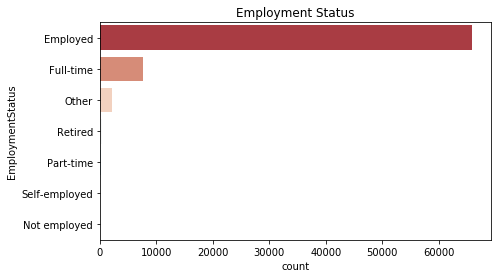

```python
plt.figure(figsize=(7, 4))
sns.countplot(data=loan_clean,y="EmploymentStatus", palette="RdBu",order=loan_clean.EmploymentStatus.value_counts().index)
plt.title("Employment Status")
```

**Note:** Most of the borrowers are employed and full-time worker.

### 5. Income Range

**The income range of the borrower at the time the listing was created.**

```python
loan_clean.IncomeRange.value_counts()
```

```
$50,000-74,999    23692
$25,000-49,999    21421
$100,000+         13977
$75,000-99,999    13547
$1-24,999          3578
Not employed          1
Name: IncomeRange, dtype: int64
```

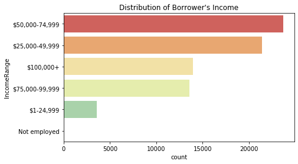

```python
plt.figure(figsize=(7, 4))
sns.countplot(data=loan_clean,y="IncomeRange", palette="Spectral")
plt.title("Distribution of Borrower's Income")
```

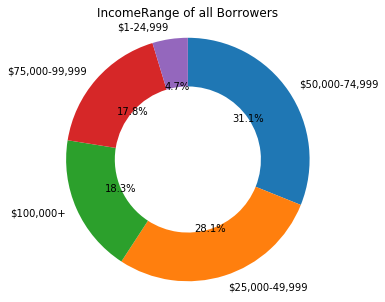

```python
loan_df= loan_clean[loan_clean['IncomeRange'] != 'Not employed']
plt.figure(figsize=(7, 5))
sorted_counts = loan_df['IncomeRange'].value_counts()
plt.pie(sorted_counts, labels = sorted_counts.index, startangle = 90,
        counterclock = False, wedgeprops = {'width' : 0.4}, autopct   = '%.1f%%');
plt.title("IncomeRange of all Borrowers")
plt.axis('square');
```

```python
#It is an odd case were loan was granted and the status is completed now, even though the person is not employed
loan_clean[loan_clean.IncomeRange=="Not employed"]
```

|  | ListingKey | ListingNumber | Term | LoanStatus | EstimatedEffectiveYield | BorrowerAPR | BorrowerRate | ProsperRating_Numeric | ProsperRating_Alpha | ProsperScore | ... | IncomeVerifiable | StatedMonthlyIncome | MonthlyLoanPayment | Recommendations | DebtToIncomeRatio | LoanOriginalAmount | PercentFunded | IncomeRange | Investors | BorrowerState |
| --- | --- | --- | --- | --- | --- | --- | --- | --- | --- | --- | --- | --- | --- | --- | --- | --- | --- | --- | --- | --- | --- |
| 21386 | BC0C3466047510716AB85FC | 429702 | 36 | Completed | 0.1331 | 0.288 | 0.249 | 3.0 | D | 8.0 | ... | True | 2167.583333 | 39.71 | 0 | 0.34 | 1000 | 1.0 | Not employed | 23 | MN |

1 rows × 25 columns

**Note:** There are very few people(4.7%) with income less than $24,999..  
We have an odd case where an a person is not employed and had applied for loan.

### 6. ProsperRating (Alpha)

**The Prosper Rating assigned at the time the listing was created between AA - HR. Applicable for loans originated after July 2009. The rating assigned by Prosper helps to decide the APR the borrower should be charged.**

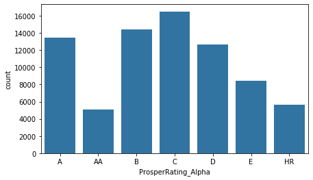

```python
base_color = sns.color_palette()[0]
plt.figure(figsize=(7, 4))
sns.countplot(data=loan_clean,x="ProsperRating_Alpha",order=["A","AA","B","C","D","E","HR"],color=base_color)
```

**Note:**Loans with "AA" category are with lesser count

### 7. ProsperScore

A custom risk score was built using historical Prosper data to assess the risk of Prosper borrower listings. The output to Prosper users is a Prosper score which ranges from 1 to 11, with 11 being the best, or lowest risk, score. The worst, or highest risk, score, is a 1.  
Prosper uses both the custom score and the credit reporting agency score together to assess the borrower’s level of risk and determine estimated loss rates. For detailed explanation:https://www.prosper.com/plp/general-prosper_score/

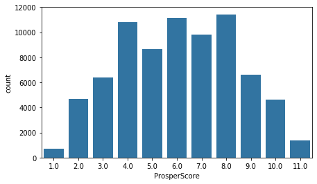

```python
plt.figure(figsize=(7, 4))
base_color = sns.color_palette()[0]
sns.countplot(data=loan_clean,x="ProsperScore",color=base_color)
```

**Note:** There are alot of borrower's with prosperScore less than 6.0. Based on this we can say loan was even provided to people with high risk score.

### 8. Borrower's Occupation

**The Occupation selected by the Borrower at the time they created the listing.**

```python
pd.set_option("display.max_rows", None)
loan_clean.Occupation.value_counts()
```

```
Other                                 18501
Professional                           9916
Executive                              3206
Computer Programmer                    3038
Teacher                                2777
Analyst                                2683
Administrative Assistant               2603
Accountant/CPA                         2413
Nurse (RN)                             2121
Clerical                               2059
Skilled Labor                          2033
Sales - Commission                     1982
Retail Management                      1900
Sales - Retail                         1724
Police Officer/Correction Officer      1273
Truck Driver                           1218
Laborer                                1162
Civil Service                          1131
Engineer - Mechanical                  1098
Construction                           1052
Food Service Management                 935
Engineer - Electrical                   873
Medical Technician                      863
Military Enlisted                       797
Tradesman - Mechanic                    744
Food Service                            719
Attorney                                712
Social Worker                           551
Postal Service                          480
Professor                               436
Nurse (LPN)                             401
Tradesman - Electrician                 373
Nurse's Aide                            350
Doctor                                  336
Fireman                                 315
Scientist                               284
Waiter/Waitress                         259
Military Officer                        247
Principal                               247
Bus Driver                              240
```

[output cut: 13 more lines]

```
Student - College Graduate Student       73
Religious                                71
Tradesman - Plumber                      66
Investor                                 64
Tradesman - Carpenter                    47
Dentist                                  45
Student - College Senior                 37
Judge                                    22
Homemaker                                22
Student - College Junior                 19
Student - College Freshman               12
Student - College Sophomore               9
Student - Community College               5
Student - Technical School                1
Name: Occupation, dtype: int64
```

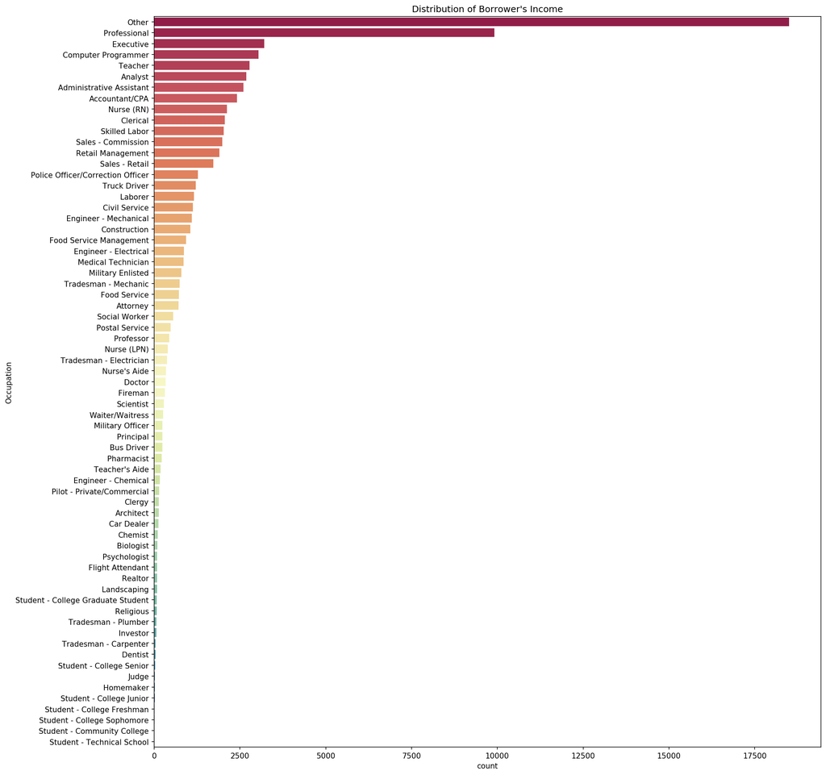

```python
plt.figure(figsize=(16, 18), dpi= 150, facecolor='w', edgecolor='k')
sns.countplot(data=loan_clean,y="Occupation", palette="Spectral",order=loan_clean.Occupation.value_counts().index)
plt.title("Distribution of Borrower's Income")
```

**Note:** Most of the borrower's didn't specify there occupation that was given in form, they wrote Other.  
**Apart from that "Professional", "Executive", "Computer Programmer", "Teacher", and "Analyst" are the top 5 most common occupations of the borrower's.**

### 9. Verifed Income

**The borrower indicated they have the required documentation to support their income.**

```python
loan_clean.IncomeVerifiable.value_counts()
```

```
True     76168
False       48
Name: IncomeVerifiable, dtype: int64
```

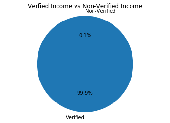

```python
labels = ["Verified","Non-Verified"]
sizes = loan_clean.IncomeVerifiable.value_counts()

fig1, ax1 = plt.subplots()
ax1.pie(sizes, labels=labels, autopct='%1.1f%%',
       startangle=90)
ax1.axis('equal')  # Equal aspect ratio ensures that pie is drawn as a circle.
plt.title("Verfied Income vs Non-Verified Income")
```

**Note:** There are 0.1% borrowers without verfied income.

### 10. BorrowerAPR

**The Borrower's Annual Percentage Rate (APR) for the loan.**

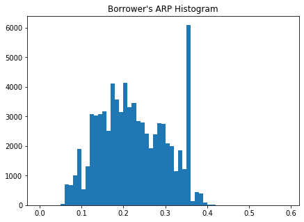

```python
plt.figure(figsize=(7, 5))
plt.hist(loan_clean.BorrowerAPR,bins=np.arange(0,0.6,0.01))
plt.title("Borrower's ARP Histogram")
```

```python
loan_clean.BorrowerAPR.describe()
```

```
count    76216.000000
mean         0.223901
std          0.079372
min          0.045830
25%          0.161570
50%          0.215660
75%          0.287800
max          0.423950
Name: BorrowerAPR, dtype: float64
```

**Note:** 50% of borrowerARP is in range of 0.161570 - 0.287800

### 11. Borrower Rate

**The Borrower's interest rate for this loan.**

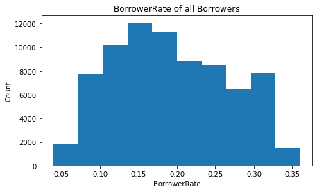

```python
plt.figure(figsize=(7, 4))
plt.hist(data = loan_clean, x = 'BorrowerRate');
plt.xlabel('BorrowerRate');
plt.ylabel('Count');
plt.title("BorrowerRate of all Borrowers");
```

**Note:**The Borrower's interest rate for this loan. The borrowers rate follow an approximately unimodal distribution, with the peak around 0.16

### 12.Monthly Income of Borrowers

**The monthly income the borrower stated at the time the listing was created.**

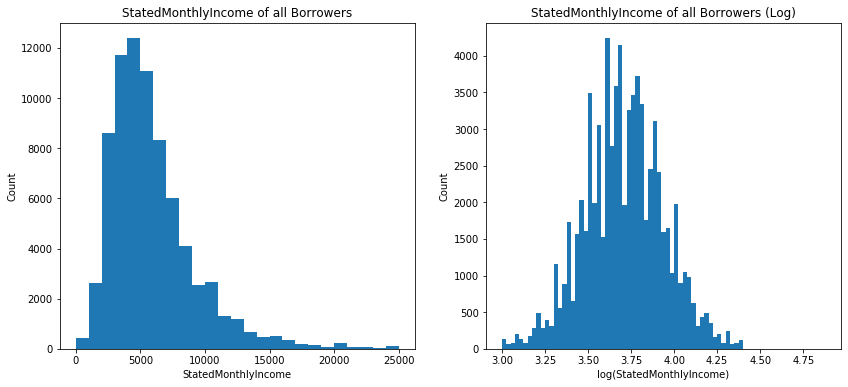

```python
loan_clean_sub = loan_clean[loan_clean['StatedMonthlyIncome'] <= 25000]
plt.figure(figsize = [14, 6])

# left histogram: data plotted in natural units
plt.subplot(1, 2, 1)
bin_edges = np.arange(0, loan_clean_sub['StatedMonthlyIncome'].max()+1000, 1000)
plt.hist(data =loan_clean_sub, x = 'StatedMonthlyIncome', bins = bin_edges)
plt.xlabel('StatedMonthlyIncome')
plt.ylabel('Count');
plt.title("StatedMonthlyIncome of all Borrowers");

# right histogram: data plotted after direct log transformation
plt.subplot(1, 2, 2)
log_data = np.log10(loan_clean_sub['StatedMonthlyIncome']) # direct data transform
log_bin_edges = np.arange(3, log_data.max()+0.5, 0.025)
plt.hist(log_data, bins = log_bin_edges)
plt.xlabel('log(StatedMonthlyIncome)');
plt.ylabel('Count');
plt.title("StatedMonthlyIncome of all Borrowers (Log)");
```

**Note:** The monthly income the borrower stated at the time the listing was created. Monthly Income will definitely be right skewed since very few people will be having a higher salary.

## Summary:

- Original Loan amount is right skewed. Most of the loan amount are in range of 0-5000.
- Most of the Loan status is Current. Apart from it we can see alot of completed loan case.
- 54.4% of the borrower's are homeowner.
- Most of the borrowers are employed amd full-time worker.
- There are very few people(4.7%) with income less than 24,999.
- Loans with "AA" category are with lesser count
- There are alot of borrower's with prosperScore less than 6.0. Based on this we can say loan was even provided to people with high risk score.
- Most of the borrower's didn't specify there occupation that was given in form, they wrote Other.
- Apart from that "Professional", "Executive", "Computer Programmer", "Teacher", and "Analyst" are the top 5 most common occupations of the borrower's.
- There are 0.1% borrowers without verfied income.
- 50% of borrowerARP is in range of 0.161570 - 0.287800
- The borrowers rate follow an approximately unimodal distribution, with the peak around 0.16
- The monthly income the borrower stated at the time the listing was created. Monthly Income will definitely be right skewed since very few people will be having a higher salary.

# Bivariate Exploration

## 1. Correlation between important numeric variables

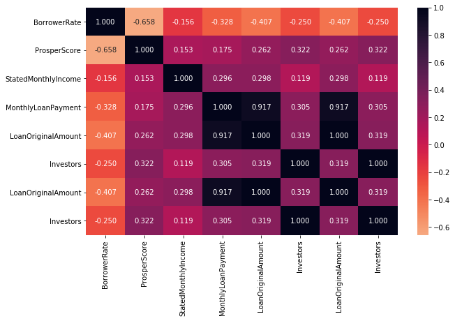

```python
cols=['BorrowerRate', 'ProsperScore', 'StatedMonthlyIncome', 'MonthlyLoanPayment', 'LoanOriginalAmount', 'Investors' ,
      'LoanOriginalAmount', 'Investors']
plt.figure(figsize = [10, 6])
sns.heatmap(loan_clean[cols].corr(), annot = True, fmt = '.3f',cmap = 'rocket_r', center = 0)
plt.show()
```

**Note:**

- Negative correlation between BorrowerRate and Prosper Score, means lower the prosper rate, higher will be the borrower rate
- Higher loan amount is associated with high monthly payment, as they are have strong positive correlation.

### Monthly Payment vs Loan Amount

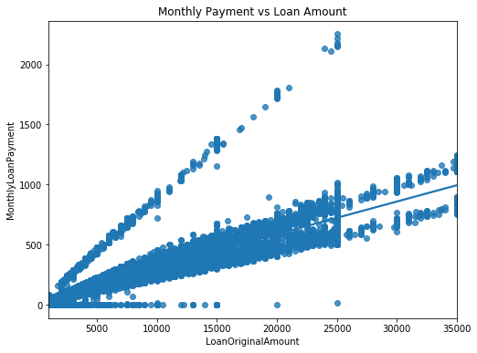

```python
plt.figure(figsize = [8, 6])
sns.regplot(data = loan_clean, x = 'LoanOriginalAmount', y ="MonthlyLoanPayment")
plt.title("Monthly Payment vs Loan Amount")
```

### Borrower Interest Rate vs Prosper score

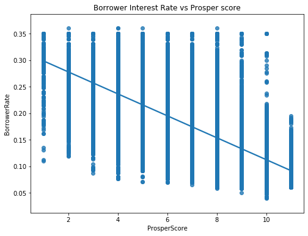

```python
plt.figure(figsize = [8, 6])
sns.regplot(data = loan_clean, x = 'ProsperScore', y ="BorrowerRate")
plt.title("Borrower Interest Rate vs Prosper score")
```

### Loan Amount vs Borrower Interest Rate

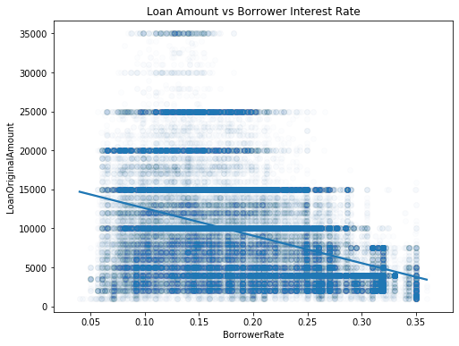

```python
plt.figure(figsize = [8, 6])
sns.regplot(data = loan_clean, x = 'BorrowerRate', y ="LoanOriginalAmount",scatter_kws = {'alpha' : 1/100})
plt.title("Loan Amount vs Borrower Interest Rate")
```

**Conclusion:**

- Loan original amount and monthly loan payment is highly positive correlated,
- Borrowers interest rate and proper score are highly negatively correlated,
- and Borrower interest rate and Loan original amount are negatively correlated.

## 2. Numeric & Categorical variables

### Relationship between ProsperScore and Employment Status

Question: Can we conclude anything regarding the relationship between ProsperScore and Employment Status??

```
(-1.1979166398282335, 12.545199039718295)
```

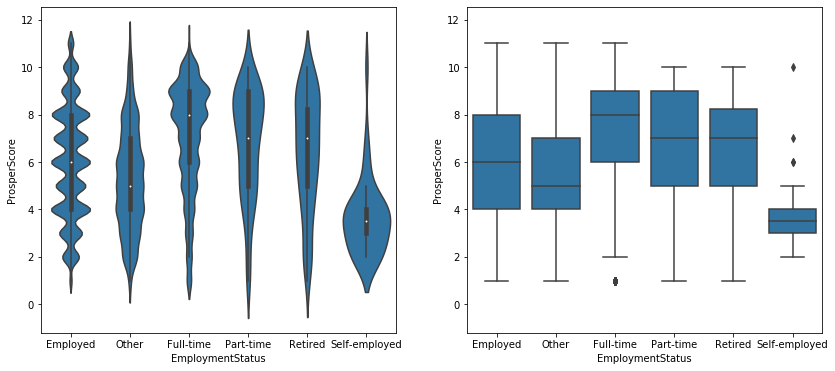

```python
plt.figure(figsize = [14, 6])
base_color = sns.color_palette()[0]

# left plot: violin plot
plt.subplot(1, 2, 1)
ax1 = sns.violinplot(data = loan_df, x = 'EmploymentStatus', y = 'ProsperScore', color = base_color)

# right plot: box plot
plt.subplot(1, 2, 2)
sns.boxplot(data = loan_df, x = 'EmploymentStatus', y = 'ProsperScore', color = base_color)
plt.ylim(ax1.get_ylim()) # set y-axis limits to be same as left plot
```

#### Conslusion:

- Full-time employs have generally high prosper rating than others, and have better chance of getting loan easily with lesser borrower interest rate.
- Self-employed people have low prosper rating, thus it's hard for them to get high loan amount with lesser borrower interest rate.

### Relationship between Loan Status and Prosper Score

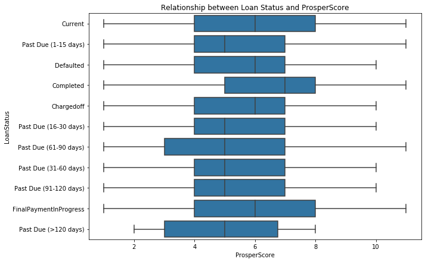

```python
plt.figure(figsize = [10, 7])
base_color = sns.color_palette()[0]

sns.boxplot(data = loan_clean, y = 'LoanStatus', x = 'ProsperScore', color = base_color)
plt.title("Relationship between Loan Status and ProsperScore")
```

```python
loan_clean.columns
```

```
Index(['ListingKey', 'ListingNumber', 'Term', 'LoanStatus',
       'EstimatedEffectiveYield', 'BorrowerAPR', 'BorrowerRate',
       'ProsperRating_Numeric', 'ProsperRating_Alpha', 'ProsperScore',
       'ListingCategory_Numeric', 'EmploymentStatus', 'Occupation',
       'EmploymentStatusDuration', 'IsBorrowerHomeowner', 'IncomeVerifiable',
       'StatedMonthlyIncome', 'MonthlyLoanPayment', 'Recommendations',
       'DebtToIncomeRatio', 'LoanOriginalAmount', 'PercentFunded',
       'IncomeRange', 'Investors', 'BorrowerState'],
      dtype='object')
```

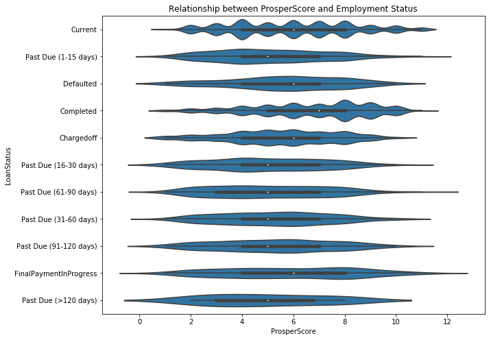

```python
plt.figure(figsize = [10, 8])
base_color = sns.color_palette()[0]
sns.violinplot(data = loan_clean, y = 'LoanStatus', x = 'ProsperScore', color = base_color)
plt.title("Relationship between ProsperScore and Employment Status")
```

### Relationship between Occupation and Loan Amount

Question : Which Occupants generally have high loan amount than others??

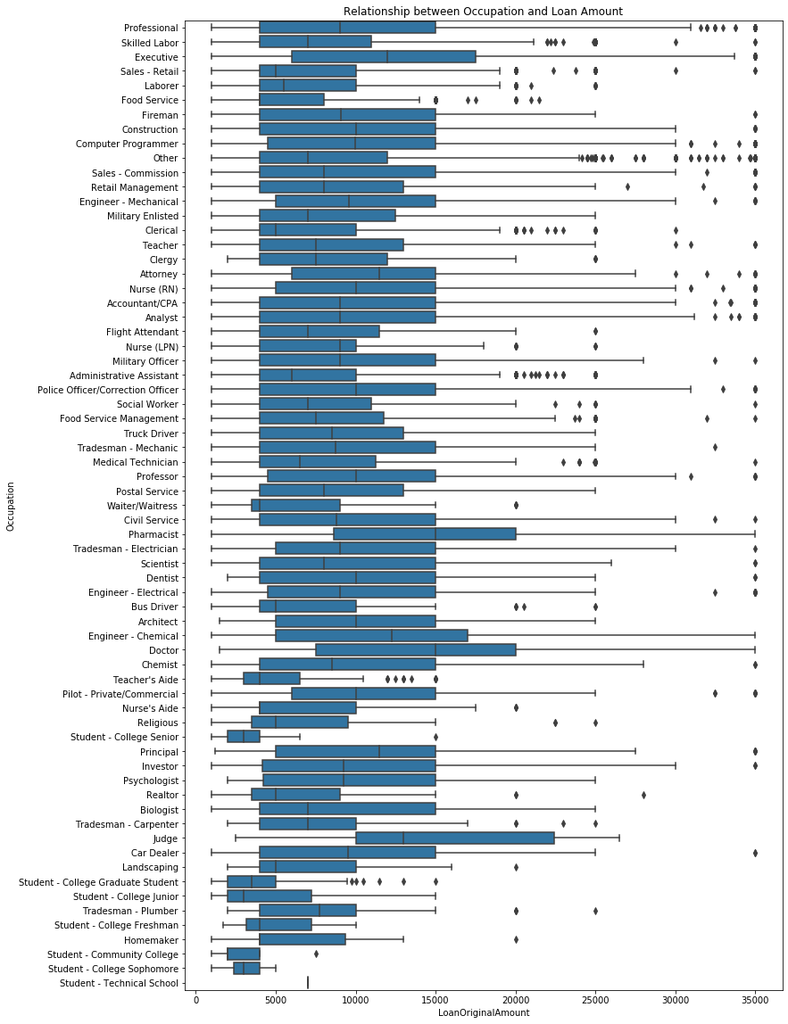

```python
plt.figure(figsize = [12, 20])
base_color = sns.color_palette()[0]
sns.boxplot(data = loan_clean, y = 'Occupation', x = 'LoanOriginalAmount', color = base_color) # set y-axis limits to be same as left plot
plt.title("Relationship between Occupation and Loan Amount")
```

**Conclusion:**

- Executives, Pharmacist, Doctors and Judge have large loan amount in comparision to other occupants

### Income Range vs Loan Amount

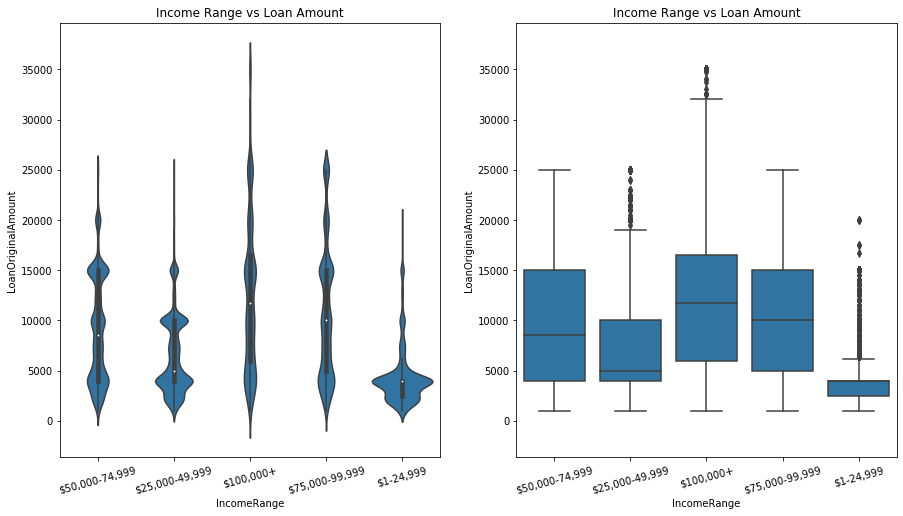

```python
loan_clean_sub = loan_clean[(loan_clean['StatedMonthlyIncome'] <= 10000) ]
loan_clean_sub = loan_clean_sub[loan_clean_sub['IncomeRange'] != 'Not employed']


plt.figure(figsize = [15, 8])
base_color = sns.color_palette()[0]

# left plot: violin plot
plt.subplot(1, 2, 1)
ax1 = sns.violinplot(data = loan_clean_sub, x = 'IncomeRange', y = 'LoanOriginalAmount', color = base_color)
plt.xticks(rotation = 15);
plt.title('Income Range vs Loan Amount')

# right plot: box plot
plt.subplot(1, 2, 2)
sns.boxplot(data = loan_clean_sub, x = 'IncomeRange', y = 'LoanOriginalAmount', color = base_color)
plt.ylim(ax1.get_ylim()) # set y-axis limits to be same as left plot
plt.xticks(rotation = 15);
plt.title('Income Range vs Loan Amount')
```

**Conclusion:**

- People with high Income range took high loan amount.

## 3. Categorical variables

### Plot between EmploymentStatus, ProsperRating_Alpha and IncomeRange

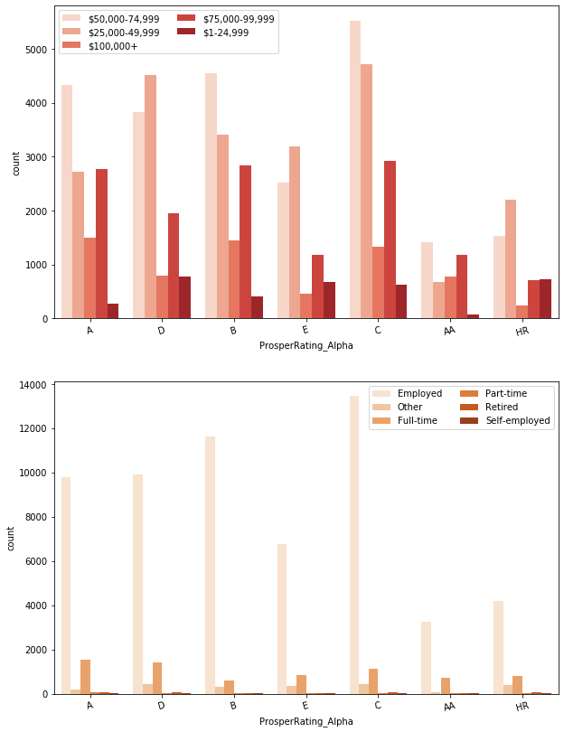

```python
# since there's only three subplots to create, using the full data should be fine.
categoric_vars = ['EmploymentStatus', 'ProsperRating_Alpha', 'IncomeRange']

plt.figure(figsize = [10, 14])

# subplot 2: clarity vs. cut
ax = plt.subplot(2, 1, 1)
sns.countplot(data = loan_clean_sub, x = 'ProsperRating_Alpha', hue = 'IncomeRange', palette = 'Reds')
ax.legend(ncol = 2) # re-arrange legend to reduce overlapping
plt.xticks(rotation = 15)


# subplot 3: clarity vs. color, use different color palette
ax = plt.subplot(2, 1, 2)
sns.countplot(data = loan_clean_sub, x = 'ProsperRating_Alpha', hue = 'EmploymentStatus', palette = 'Oranges')
ax.legend(loc = 1, ncol = 2) # re-arrange legend to remove overlapping
plt.xticks(rotation = 15)


plt.show()
```

**Note:**

- Prosper Rating B and C have most number of people who are employed.
- Borrowers with salary range are between $50,000-$74,999 are mostly in prosper rating of A, B, C or D.

### Employment Status with respect to Income Range

[figure not shown]

```python
plt.figure(figsize = [8, 8])
g = sns.FacetGrid(data = loan_clean_sub, col = 'IncomeRange',col_wrap = 3,size=5)
g.map(plt.hist, "EmploymentStatus")
```

### Count of Borrowers w.r.t LoanStatus and HomeownerStatus

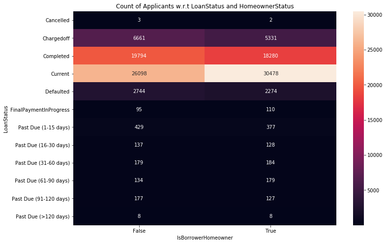

```python
plt.figure(figsize = [12, 8])
ct_counts = df.groupby(['IsBorrowerHomeowner', 'LoanStatus']).size()
ct_counts = ct_counts.reset_index(name = 'count')
ct_counts = ct_counts.pivot(index = 'LoanStatus', columns = 'IsBorrowerHomeowner', values = 'count')
sns.heatmap(ct_counts, annot = True, fmt = 'd');
plt.title('Count of Applicants w.r.t LoanStatus and HomeownerStatus')
```

## Summary:

- Negative correlation between BorrowerRate and Prosper Score, means lower the prosper rate, higher will be the borrower rate
- Higher loan amount is associated with high monthly payment, as they are have strong positive correlation.
- Loan original amount and monthly loan payment is highly positive correlated,
- Borrowers interest rate and proper score are highly negatively correlated,
- Borrower interest rate and Loan original amount are negatively correlated.
- Full-time employs have generally high prosper rating than others.
- Self-employed people have low prosper rating
- Executives, Pharmacist, Doctors and Judge have large loan amount in comparision to other occupants
- People with high Income range took high loan amount.
- Prosper Rating B and C have most number of people who are employed.
- Borrowers with salary range are between 50,000− 74,999 are mostly in prosper rating of A, B, C or D.

## Multivariate Visualization

### Reationship between Loan Amount, Prosper Score and Monthly Loan Payment

Question: Is there any relation between these variable??

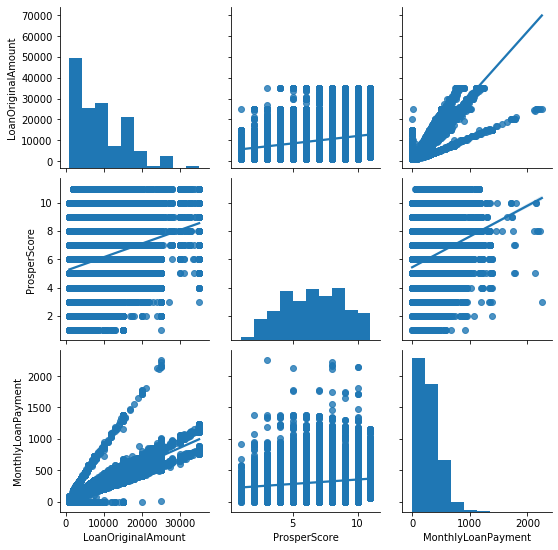

```python
g = sns.PairGrid(data = loan_clean, vars = ['LoanOriginalAmount', 'ProsperScore', 'MonthlyLoanPayment'])
g.map_diag(plt.hist)
g.map_offdiag(sns.regplot)
```

### Multivariable Exploration

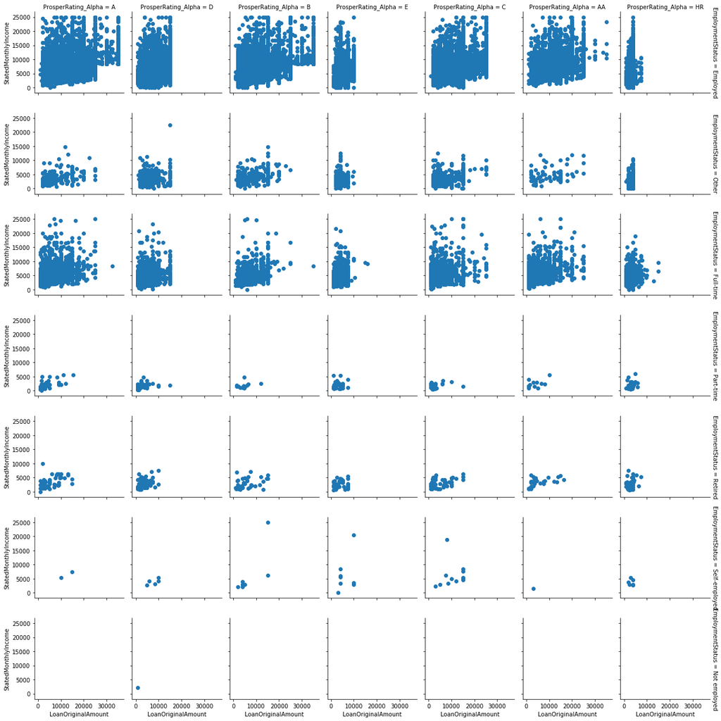

```python
g = sns.FacetGrid(data = loan_clean_sub, col = 'ProsperRating_Alpha', row = 'EmploymentStatus', size = 2.5,
                margin_titles = True)
g.map(plt.scatter, 'LoanOriginalAmount', 'StatedMonthlyIncome');
```

#### NOTES:

- Based on the Prosper Rating we can conclude that large amount of amount of loan is easily provided to those who have high monthly salary and are employed or full-time worker.
- Employment Status And Monthly Salary can be considered few parameter that affected Prosper Rating.

### Mean monthly Income across Prosper Rating and Employment Status

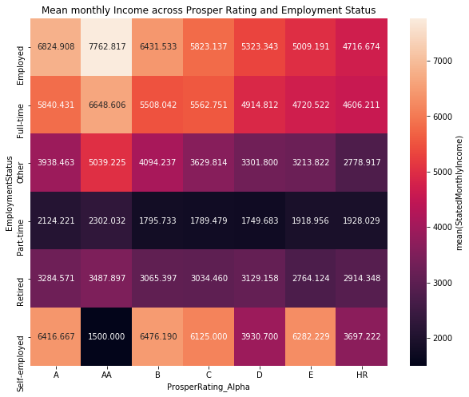

```python
plt.figure(figsize = [10, 8])
loan_clean_sub = loan_clean_sub[loan_clean_sub.EmploymentStatus != 'Not employed']
cat_means = loan_clean_sub.groupby(['ProsperRating_Alpha', 'EmploymentStatus']).mean()['StatedMonthlyIncome']
cat_means = cat_means.reset_index(name = 'StatedMonthlyIncome_avg')
cat_means = cat_means.pivot(index = 'EmploymentStatus', columns = 'ProsperRating_Alpha',values = 'StatedMonthlyIncome_avg')
sns.heatmap(cat_means, annot = True, fmt = '.3f',cbar_kws = {'label' : 'mean(StatedMonthlyIncome)'});
plt.title('Mean monthly Income across Prosper Rating and Employment Status');
```

#### Note:

- Employed, Self-employed and full-time borrowers generally have high monthly amount